# Impact of Severe Weather on Human and Economic Health in the United States

## Synopsis

This research aims to identify the impact of severe weather on human and economic heath in the United States.The research uses data provided by the National Oceanic and Atmospheric Administration???s (NOAA), covering the years 1950-2011 and reports the number of death and damage to property and crops. The data analysis shows that tornados are the most dangerous for human heath and floods are the most dangerous for poperty.

```r
knitr::opts_chunk$set(echo = TRUE)
```

## Data Processing

Useful libraries were loaded and data was read from local directory (it will take some time) and glaced at the variables reported. The relevant variables for the analysis are: - EVTYPE - FATALITIES - INJURIES - PROPDMG - PROPDMGEXP - CROPDMG - CROPDMGEXP

```r
#library(tinytext)
library(plyr)
library(ggplot2)
library(dplyr)
stormdata<- read.csv("/Users/iMac/datasciencecoursera/repdata_data_StormData.csv")

storm<-stormdata[c("EVTYPE", "FATALITIES", "INJURIES", "PROPDMG", "PROPDMGEXP", "CROPDMG", "CROPDMGEXP")]

str(storm)
```

```
## 'data.frame':    902297 obs. of  7 variables:
##  $ EVTYPE    : Factor w/ 985 levels "   HIGH SURF ADVISORY",..: 834 834 834 834 834 834 834 834 834 834 ...
##  $ FATALITIES: num  0 0 0 0 0 0 0 0 1 0 ...
##  $ INJURIES  : num  15 0 2 2 2 6 1 0 14 0 ...
##  $ PROPDMG   : num  25 2.5 25 2.5 2.5 2.5 2.5 2.5 25 25 ...
##  $ PROPDMGEXP: Factor w/ 19 levels "","-","?","+",..: 17 17 17 17 17 17 17 17 17 17 ...
##  $ CROPDMG   : num  0 0 0 0 0 0 0 0 0 0 ...
##  $ CROPDMGEXP: Factor w/ 9 levels "","?","0","2",..: 1 1 1 1 1 1 1 1 1 1 ...
```

```r
head(storm)
```

```
##    EVTYPE FATALITIES INJURIES PROPDMG PROPDMGEXP CROPDMG CROPDMGEXP
## 1 TORNADO          0       15    25.0          K       0
## 2 TORNADO          0        0     2.5          K       0
## 3 TORNADO          0        2    25.0          K       0
## 4 TORNADO          0        2     2.5          K       0
## 5 TORNADO          0        2     2.5          K       0
## 6 TORNADO          0        6     2.5          K       0
```

```r
summary(storm)
```

```
##                EVTYPE         FATALITIES          INJURIES
##  HAIL             :288661   Min.   :  0.0000   Min.   :   0.0000
##  TSTM WIND        :219940   1st Qu.:  0.0000   1st Qu.:   0.0000
##  THUNDERSTORM WIND: 82563   Median :  0.0000   Median :   0.0000
##  TORNADO          : 60652   Mean   :  0.0168   Mean   :   0.1557
##  FLASH FLOOD      : 54277   3rd Qu.:  0.0000   3rd Qu.:   0.0000
##  FLOOD            : 25326   Max.   :583.0000   Max.   :1700.0000
##  (Other)          :170878
##     PROPDMG          PROPDMGEXP        CROPDMG          CROPDMGEXP
##  Min.   :   0.00          :465934   Min.   :  0.000          :618413
##  1st Qu.:   0.00   K      :424665   1st Qu.:  0.000   K      :281832
##  Median :   0.00   M      : 11330   Median :  0.000   M      :  1994
##  Mean   :  12.06   0      :   216   Mean   :  1.527   k      :    21
##  3rd Qu.:   0.50   B      :    40   3rd Qu.:  0.000   0      :    19
##  Max.   :5000.00   5      :    28   Max.   :990.000   B      :     9
##                    (Other):    84                     (Other):     9
```

Property Damage (PROPDMG) and Crop Damage (CROPDMG) must be converted to numeric variables and converted to comparable scales.

```r
storm$PROPDMGEXP<- mapvalues(storm$PROPDMGEXP, from = c("K", "M","", "B", "m", "+", "0", "5", "6", "?", "4", "2", "3", "h", "7", "H", "-", "1", "8"), to = c(10^3, 10^6, 1, 10^9, 10^6, 0,1,10^5, 10^6, 0, 10^4, 10^2, 10^3, 10^2, 10^7, 10^2, 0, 10, 10^8))

storm$PROPDMGEXP<- as.numeric(as.character(storm$PROPDMGEXP))

storm$PROPDMGTOTAL<- (storm$PROPDMG * storm$PROPDMGEXP)/1000000000

storm$CROPDMGEXP<- mapvalues(storm$CROPDMGEXP, from = c("","M", "K", "m", "B", "?", "0", "k","2"), to = c(1,10^6, 10^3, 10^6, 10^9, 0, 1, 10^3, 10^2))

storm$CROPDMGEXP<- as.numeric(as.character(storm$CROPDMGEXP))

storm$CROPDMGTOTAL<- (storm$CROPDMG * storm$CROPDMGEXP)/1000000000

storm$DAMAGETOTAL<- storm$PROPDMGTOTAL + storm$CROPDMGEXP

detach(package:plyr)
```

Grouping and ploting related data to understand fatalities by cause.

```r
storm_type<- storm %>%
  mutate(evtypegrp = ifelse(grepl("LIGHTNING|LIGNTNING", EVTYPE), "LIGHTNING", ifelse(grepl("HAIL", EVTYPE), "HAIL", ifelse(grepl("RAIN|FLOOD|WET|FLD", EVTYPE), "RAIN", ifelse(grepl("SNOW|WINTER|WINTRY|BLIZZARD|SLEET|COLD|ICE|FREEZE|AVALANCHE|ICY", EVTYPE), "WINTER",
ifelse(grepl("TORNADO|FUNNEL", EVTYPE), "TORNADO",
ifelse(grepl("WIND|HURRICANE", EVTYPE), "WINDS",
ifelse(grepl("STORM|THUNDER|TSTM|TROPICAL +STORM", EVTYPE), "STORM",
ifelse(grepl("FIRE", EVTYPE), "FIRE",
ifelse(grepl("FOG|VISIBILITY|DARK|DUST", EVTYPE), "FOG",
ifelse(grepl("WAVE|SURF|SURGE|TIDE|TSUNAMI|CURRENT|SWELL", EVTYPE), "WAVE",
ifelse(grepl("HEAT|HIGH +TEMP|RECORD +TEMP|WARM|DRY", EVTYPE), "HEAT",
ifelse(grepl("VOLCAN", EVTYPE), "VOLCANO",
ifelse(grepl("DROUGHT", EVTYPE), "DROUGHT","OTHER"))))))))))))))
```

Plotting fatalities

```r
event_sum<- storm_type %>% group_by(evtypegrp) %>% summarise(damage = sum(DAMAGETOTAL), property= sum(PROPDMGTOTAL), crops = sum(CROPDMGTOTAL), fatalities = sum(FATALITIES), injuries = sum(INJURIES))
```

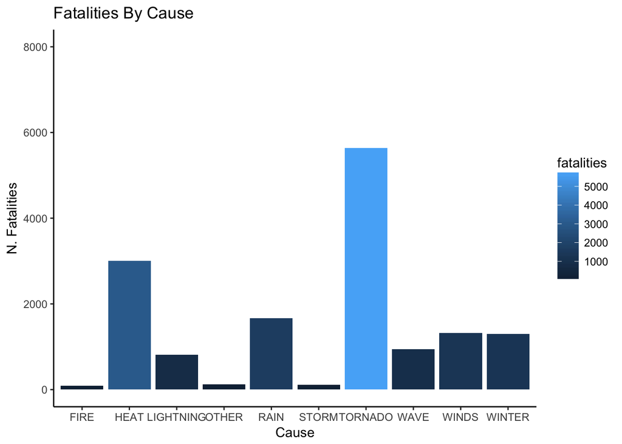

```r
fatalities<-head(event_sum[order(event_sum$fatalities, decreasing=TRUE),],10)


ggplot(fatalities, aes(evtypegrp,fatalities, fill=fatalities)) + geom_bar(stat = "identity") + labs(x= "Cause", y = "N. Fatalities") +
  ggtitle("Fatalities By Cause")+
  theme_classic() +
  expand_limits(y=c(0,8000))
```

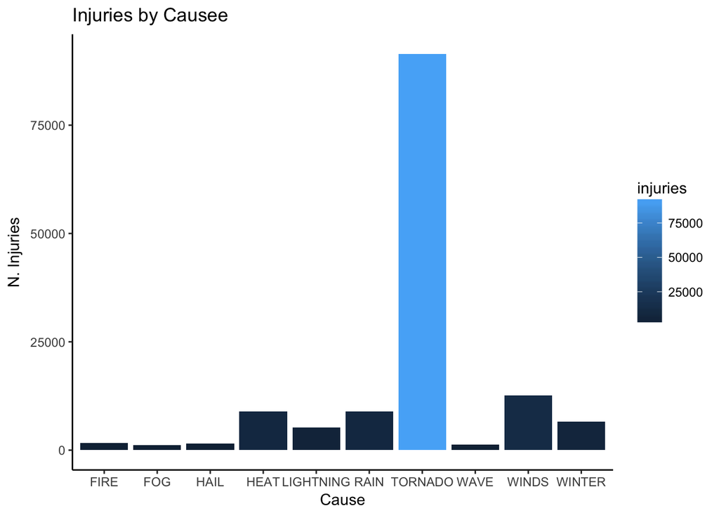

```r
injuries<- head(event_sum[order(event_sum$injuries, decreasing = TRUE),], 10)

ggplot(injuries, aes(evtypegrp, injuries, fill=injuries)) + geom_bar(stat = "identity") + labs(x = "Cause", y = "N. Injuries") + ggtitle("Injuries by Causee")+ theme_classic() + expand_limits(y=c(0, 8000))
```

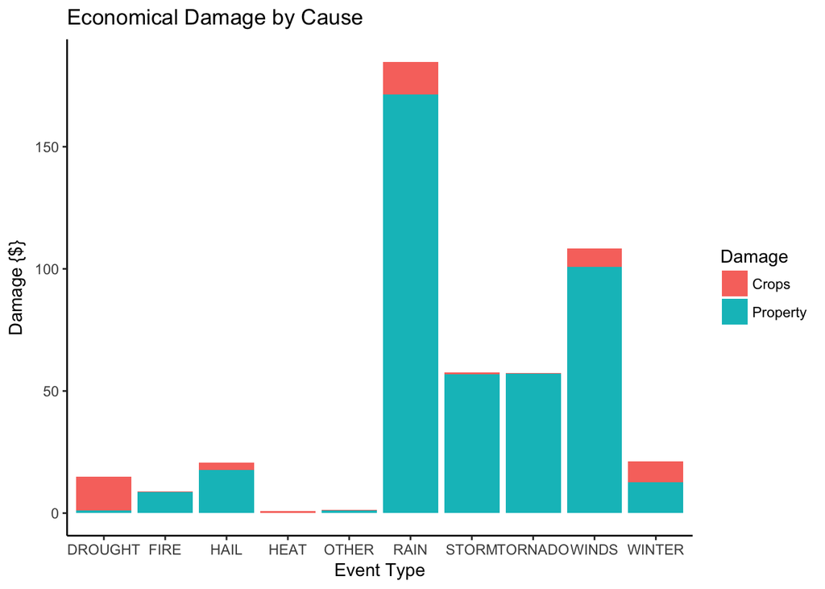

```r
damage <-head(event_sum[order(event_sum$damage, decreasing=TRUE),],10)
property <- damage %>% mutate(damage_type="Property", damage_amount=property)
crops <- damage %>% mutate(damage_type="Crops", damage_amount=crops)
damage_major <- rbind(property,crops)

ggplot(damage_major, aes(evtypegrp, damage_amount, fill=factor(damage_type))) +
  geom_bar(stat = "identity") +
  ylab("Damage {$}") +
  xlab("Event Type") +
  scale_fill_discrete(name = "Damage") +
  ggtitle ("Economical Damage by Cause") +
  theme_classic()
```